# Project 1

Luke Perkins

2022-09-14

**Purpose:** The purpose of this document is to demonstrate how customized functions can be created to process, manipulate, and plot data. The report will be divided into four sections:

1. Data Processing
2. Combining Data
3. Generic Functions
4. Putting It All Together

## Data Processing

The functions below integrate other functions from the `tidyverse`, therefore, relevant packages must be read in using `library(tidyverse)` before any code is run. This has been done in the R Markdown setup code chunk of the document.

### Selecting and Reshaping

The first function created takes a data frame with certain specifications and subsets the columns, renames a variable, and reshapes the data.

```r
selectreshape <- function(df, values_to = "enrollment") {
  df %>%
    select(Area_name, STCOU, ends_with("D")) %>%
    rename(area_name = "Area_name") %>%
    pivot_longer(cols = 3:12, names_to = "survey_id", values_to = values_to)
}
```

### Year and Measurement Parsing

The second function created takes the data frame output from the first function (or a data frame in the same format), and creates two new columns from the `survey_id` column: the year, `year`, and the type of value from the survey, `measurement`.

Using the `substr()` function, the eighth and ninth characters of `survey_id` are extracted, which correspond with the last two digits of the year. The extracted values are converted to numeric type using the `as.numeric()` function. Coercing the type to numeric allows for arithmetic operations in a future step. The value is then saved to a temporary variable, `yrtemp`.

Calling the `mutate` function creates two columns:

1. `year` uses the vectorized `if_else()` function to determine if each value in the `yrtemp` variable is less than or equal to 40, then adds either 2000 or 1900 based on that evaluation to convert the year to four digits.
2. `measurement` uses the `substr()` function to take the first seven characters of the `survey_id` column.

```r
parseyrmeas <- function(df) {
  yrtemp <- df$survey_id %>%
    substr(start = 8, stop = 9) %>%
    as.numeric()
  mutate(df, year = if_else(yrtemp <= 40, yrtemp + 2000, yrtemp + 1900),
         measurement = substr(df$survey_id, start = 1, stop = 7)
  )
}
```

### State Parsing

This function takes a data frame and creates a column containing the state.

Again, the `mutate` function is used to produce a column using data from another column. Here, reference column `area_name` has variable length, so the `substr()` function is used with `nchar()` and arithmetic to extract the second to last character and last character of `area_name`, based on the length of each value.

```r
parsestate <- function(df) {
  df %>%
    mutate(state = substr(area_name, nchar(area_name) - 1, nchar(area_name)))
}
```

### Division Mapping

This function’s purpose is to create a column containing the division of the state, as designated by the Census Bureau.

Here, the vectorized nature of the `if_else` function is used to produce a mapping table of sorts. The mapping checks if a value in the `area_name` column is in a vector containing state names, using the infix function `%in%`. If a match exists, the `Division` column populates with the value following the state vector. If there is no match, the check moves on to the next `if_else` chain and repeats.

Of note, “DISTRICT OF COLUMBIA” is given in both title case and upper case, and the final `if_else` function assigns a value of “ERROR” if no matches are found. All values are given as literals since they must all be the same type, and “ERROR” cannot be numeric.

```r
mapdivision <- function(df) {
  df %>%
    mutate(Division =
      if_else(df$area_name %in%
      c("CONNECTICUT", "MAINE", "MASSACHUSETTS", "NEW HAMPSHIRE",
        "RHODE ISLAND", "VERMONT"),
        "1",
      if_else (df$area_name %in%
      c("NEW JERSEY", "NEW YORK", "PENNSYLVANIA"),
        "2",
      if_else(df$area_name %in%
      c("ILLINOIS", "INDIANA", "MICHIGAN", "OHIO", "WISCONSIN"),
        "3",
      if_else(df$area_name %in%
      c("IOWA", "KANSAS", "MINNESOTA", "MISSOURI", "NEBRASKA", "NORTH DAKOTA",
        "SOUTH DAKOTA"),
        "4",
      if_else(df$area_name %in%
      c("DELAWARE", "FLORIDA", "GEORGIA", "MARYLAND", "NORTH CAROLINA",
        "SOUTH CAROLINA", "VIRGINIA", "DISTRICT OF COLUMBIA", "WEST VIRGINIA",
        "District of Columbia"),
        "5",
      if_else(df$area_name %in%
      c("ALABAMA", "KENTUCKY", "MISSISSIPPI", "TENNESSEE"),
        "6",
      if_else(df$area_name %in%
      c("ARKANSAS", "LOUISIANA", "OKLAHOMA", "TEXAS"),
        "7",
      if_else(df$area_name %in%
      c("ARIZONA", "COLORADO", "IDAHO", "MONTANA", "NEVADA", "NEW MEXICO",
        "UTAH", "WYOMING"),
        "8",
      if_else(df$area_name %in%
      c("ALASKA", "CALIFORNIA", "HAWAII", "OREGON", "WASHINGTON"),
        "9", "ERROR"))))))))))
}
```

### Separating by Type

This function parses the data into two separate files based on whether a row is associated with county data or non-county(referred to as ‘state’) data.

The input is the data frame output from the `parseyrmeas()` function. The `filter()` function subsets and separates the rows into county and state data. To do this, the `grep()` function searches for a character string pattern and returns the indices of any matches. The `row_number()` and `%in%` functions instruct the `filter()` function to subset the row numbers based on that criteria, and that output is saved as `county`. Using the same logic, complementary rows are then saved as `state`.

The `class()` function assigns classes of “county” and “state” to their respective objects. Finally, the `mapdivision()` function is called to treat the `Division` variable for the separated ‘state’ data, and the the `parsestate()` function is called to treat the state variable of the ‘county’ data. The two data frames are returned via the `return()` function in a named list.

```r
parsemulti <- function(df) {
  county <- df %>%
    filter(row_number() %in% grep(pattern = ", \\w\\w", df$area_name))
  state <- df %>%
    filter(!(row_number() %in% grep(pattern = ", \\w\\w", df$area_name)))

  class(county) <- c("county", class(county))
  class(state) <- c("state", class(state))

  dfstate <- mapdivision(state)
  dfcounty <- parsestate(county)

  return(list("state" = dfstate, "county" = dfcounty))
}
```

### Wrapping

Below is a wrapper function, or a function designed to primarily call other functions in efforts to simplify workflow.

This wrapper function calls four functions:

1. `read_csv()` reads in a .csv file from the url provided by the user as the first argument of `my_wrapper()` and converts it to a tibble, then saves it as a temporary object.
2. `selectreshape()` takes the saved tibble and reshapes it using the method described in that function’s section of this report, then saves it as a temporary object. Of note, the optional second argument in the wrapper function’s definition is passed to `selectreshape()` here to name the reshaped column.
3. `parseyrmeas()` takes the output from the prior step, parses out the `year` and `measurement` as described previously, and saves the new output as a temporary object.
4. `parsemulti()` takes the output from the prior step, separates the data into ‘state’ and ‘county’ tibbles as described previously, and stores the tibbles in a temporary object.

Finally, the `return()` function takes the output from the prior step and explicitly returns the named list of two tibbles.

```r
my_wrapper <- function(url, values_to = "enrollment") {
  url <- read_csv(url)
  a <- selectreshape(url, values_to)
  b <- parseyrmeas(a)
  c <- parsemulti(b)
  return(c)
}
```

## Combining Data

To demonstrate application of the functions, two data sets sharing a structure the `my_wrapper()` function accepts are read in and saved as `infilea` and `infileb`, with the reshaped column named as “enrollment” in both function calls.

A new function is defined, taking two data frames as arguments. The `bind_rows()` function combines the rows from the separated ‘state’ data sets and saves the output to a temporary object; similarly, the rows from the ‘county’ data sets are combined and saved to a temporary object. The newly combined ‘state’ and ‘county’ data sets are then returned in a named list, which is saved as `outfile`.

```r
infilea <- my_wrapper(url = "https://www4.stat.ncsu.edu/~online/datasets/EDU01a.csv", values_to = "enrollment")
infileb <- my_wrapper(url = "https://www4.stat.ncsu.edu/~online/datasets/EDU01b.csv", values_to = "enrollment")

combdf <- function(df1, df2) {
  dfstate <- bind_rows(df1$state, df2$state)
  dfcounty <- bind_rows(df1$county, df2$county)
  return(list("state" = dfstate, "county" = dfcounty))
}

outfile <- combdf(infilea, infileb)
```

## Generic Functions

These functions take advantage of the assigned classes of the data frames created in `parsemulti()` and `my_wrapper()` to write plotting methods.

### State Plotting

This function plots the mean value of the reshaped ‘enrollment’ across the years for each `Division`. The arguments are the data frame and the name of the reshaped ‘enrollment’ column. The data frame is subset to exclude rows with “ERROR” in the `Division` column via the `filter()` function, then is aggregated on both `year` and `Division` via the `group_by()` function. For each year and Division combination, the average enrollment is calculated as `avg_enroll` by using `summarize()` with the `mean()` function. The user-defined enrollment name used for calculation is passed with the `get()` function. The new data frame is saved as temporary object.

The stored data frame is then used as input for a time plot. The `aes()` option allows specifying of the aesthetics, with the x-axis being `year`, y-axis being the calculated statistic `avg_enroll`, and color being the `Division` variable. `geom_line()` connects the points in chronological order on the x-axis to form lines.

```r
plot.state <- function(df, var_name = "enrollment"){
  new_df <- df %>%
    filter(Division != "ERROR") %>%
    group_by(year, Division) %>%
    summarize(avg_enroll = mean(get(var_name)))

  ggplot(new_df, aes(x = year, y = avg_enroll, color = Division)) + geom_line()
}
```

### County Plotting

This function is an extension of the premise used in plotting the state data.

Using the `filter()` function, the input data frame is first subset to a specific state, either the default of “NC”, or one provided by the user. The data set is then aggregated by `area_name`. `avg_enroll` is calculated using the same methodology as before.

In this function, the user can choose to look at either the top or bottom specified number of records. To produce this effect, the data set is first sorted in order of descending enrollment via the `arrange()` and `desc()` functions. Conditional logic via `switch()` function evaluates whether the user supplies “top”(also the default) or “bottom” as an argument to evaluate the top or bottom enrollment records, respectively. If neither option is provided, the function errors out and informs the user to choose a valid option. If the user selects “top”, “head” is saved as a temporary object to `sortfn` to call the `head()` function, conversely, if “bottom” is provided, “tail” is saved as a temporary object to `sortfn` to call the `tail()` function. Because the records are sorted in descending order `head()` and `tail()` will select the top and bottom records, respectively. The number of top/bottom areas to view is specified in the `ncount` argument, which is passed to the `head()` or `tail()` function. Finally, the aggregated counts are dropped via `select()` function so that only the names of the top/bottom areas are saved as a temporary object.

The original data frame without groups is now filtered to only the top or bottom areas derived in the prior step by using `filter()` in conjunction with the `%in%` function. If the `area_name` of the original data set was included in the derived data frame, the row is included in the data set to be plotted, which is saved as a temporary object.

Using the data frame that ended the prior step, the data is plotted in a similar fashion to the state data. Changes to note are that the y-axis uses the `get()` function to pass the user-provided name of the enrollment column, and `labs()` is use to label the axis appropriately. The color variable has also been replaced with `area_name`.

```r
plot.county <- function(df, st = "NC", ncount = 5, sort = "top", var_name = "enrollment") {
  switch(sort,
               top = sortfn <- head,
               bottom = sortfn <- tail,
               stop("Sort must be top or bottom.")
  )
  subdf <- df %>%
    filter(st == state) %>%
    group_by(area_name) %>%
    summarize(avg_enroll = mean(get(var_name))) %>%
    arrange(desc(avg_enroll)) %>%
    sortfn(n = ncount) %>%
    select(area_name)

  plotdf <- df %>%
    filter(area_name %in% subdf$area_name)

  ggplot(plotdf, aes(x = year, y = get(var_name), color = area_name)) + geom_line() + labs(y = var_name)
}
```

## Putting It All Together

This final section demonstrates application of the created functions.

The first two examples read in files with the `my_wrapper()` function and specify the enrollment column as “enrollment”.

The next example uses the `combdf()` function to combine the previous outputs into a list of two data frames.

The next example runs the plot function on the output ‘state’ data frame using bracket notation to reference it as a list element.

The plot function is run on the ‘county’ data frame with the below arguments:

1. The state of Pennsylvania, the top group, and 7 areas
2. The state of Pennsylvania, the bottom group, and 4 areas
3. Default arguments
4. The state of Minnesota, the top group, and 10 areas

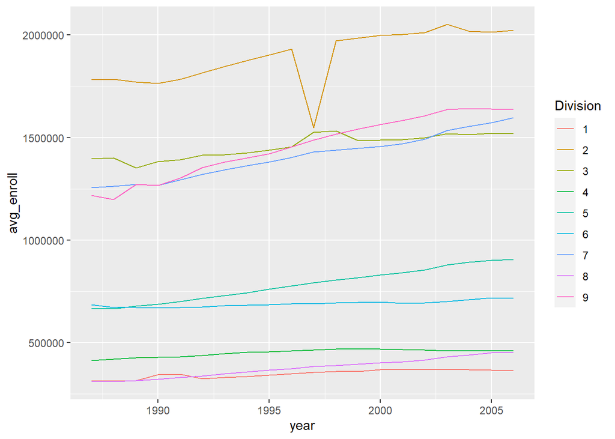

```r
infileedua <- my_wrapper(url = "https://www4.stat.ncsu.edu/~online/datasets/EDU01a.csv", values_to = "enrollment")
infileedub <- my_wrapper(url = "https://www4.stat.ncsu.edu/~online/datasets/EDU01b.csv", values_to = "enrollment")

outfileedu <- combdf(infileedua, infileedub)

plot(outfileedu[[1]])
```

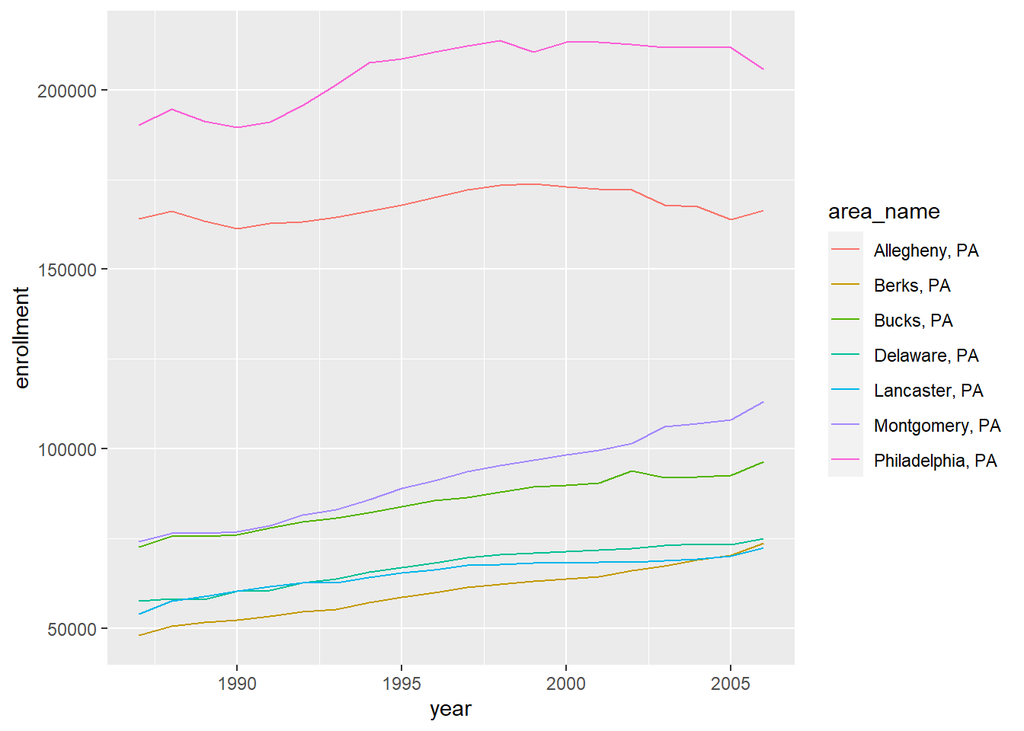

```r
plot(outfileedu[[2]], st = "PA", sort = "top", ncount = 7)
```

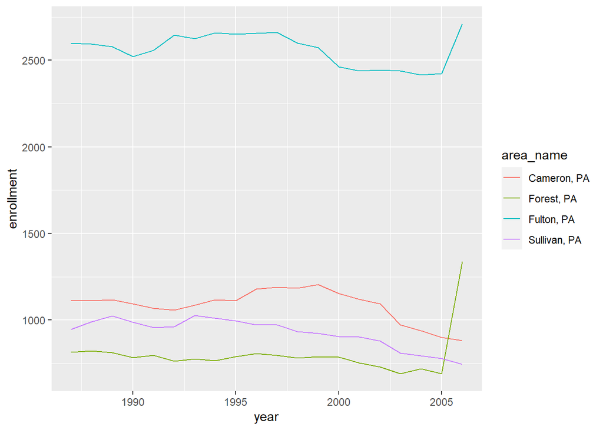

```r
plot(outfileedu[[2]], st = "PA", sort = "bottom", ncount = 4)
```

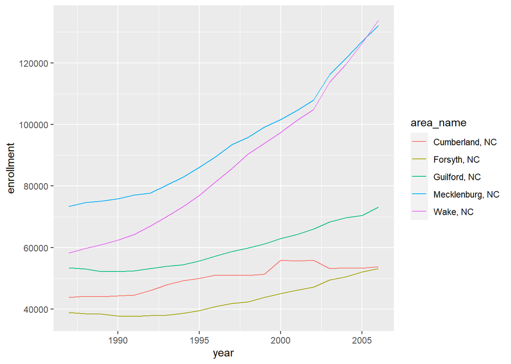

```r
plot(outfileedu[[2]])
```

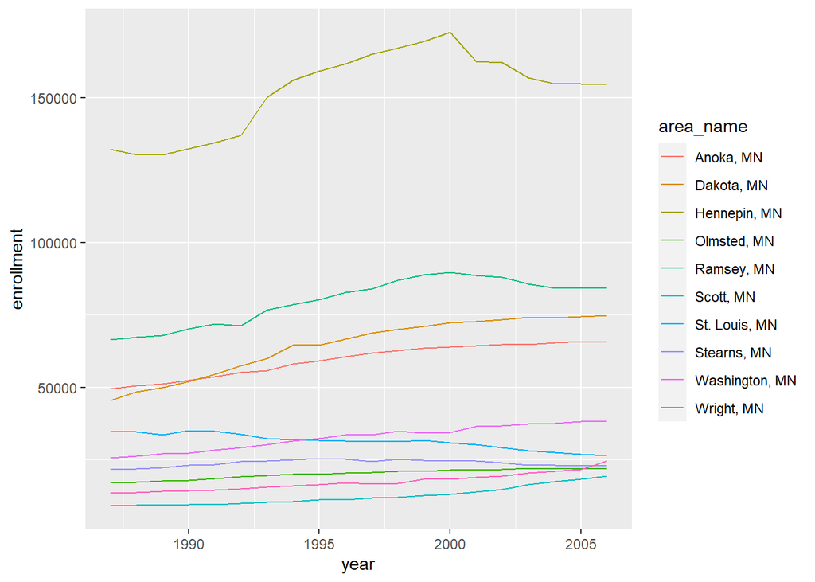

```r
plot(outfileedu[[2]], st = "MN", sort = "top", ncount = 10)
```

### Extending Applications

This section shows how the functions can be applied to other similar data sets.

The first examples read in four files with the `my_wrapper()` function and specify the enrollment column as “enrollment”.

The next example uses the `combdf()` function to combine the output data sets of the first and second files, then the third and fourth files, and finally the results of those combined files to combine all four files into a list of two data frames.

The next example runs the plot function on the output ‘state’ data frame.

As a final demonstration, the plot function is run on the ‘county’ data frame with the below arguments:

1. The state of Connecticut, the top group, and 6 areas
2. The state of North Carolina, the bottom group, and 10 areas
3. Default arguments
4. The state of Minnesota, the top group, and 4 areas

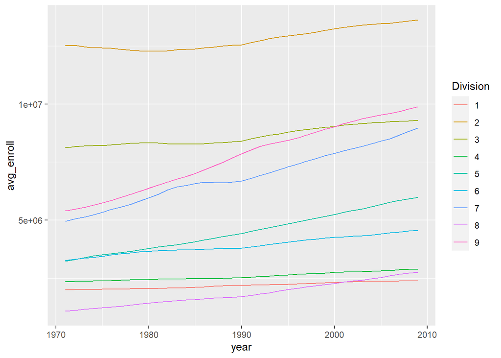

```r
infilepsta <- my_wrapper(url = "https://www4.stat.ncsu.edu/~online/datasets/PST01a.csv", values_to = "enrollment")
infilepstb <- my_wrapper(url = "https://www4.stat.ncsu.edu/~online/datasets/PST01b.csv", values_to = "enrollment")
infilepstc <- my_wrapper(url = "https://www4.stat.ncsu.edu/~online/datasets/PST01c.csv", values_to = "enrollment")
infilepstd <- my_wrapper(url = "https://www4.stat.ncsu.edu/~online/datasets/PST01d.csv", values_to = "enrollment")

outfilea <- combdf(infilepsta, infilepstb)
outfileb <- combdf(infilepstc, infilepstd)
outfilepst <- combdf(outfilea, outfileb)

plot(outfilepst$state)
```

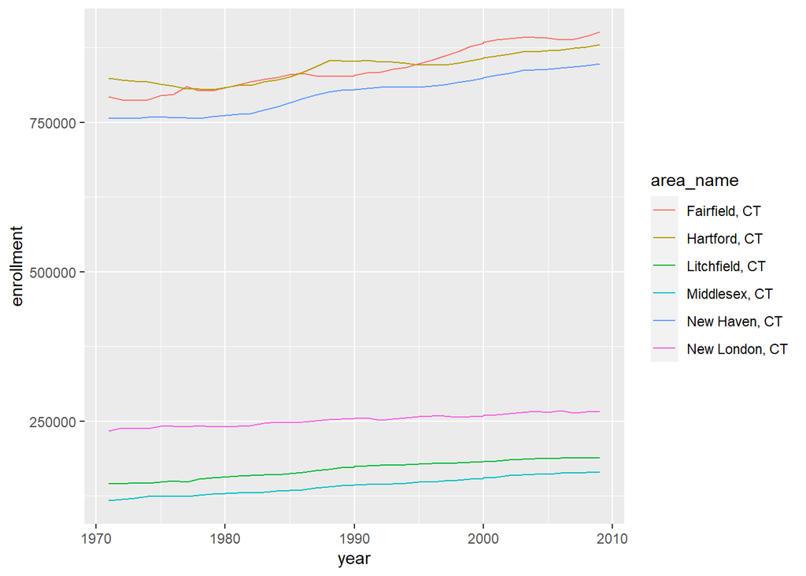

```r
plot(outfilepst$county, st = "CT", sort = "top", ncount = 6)
```

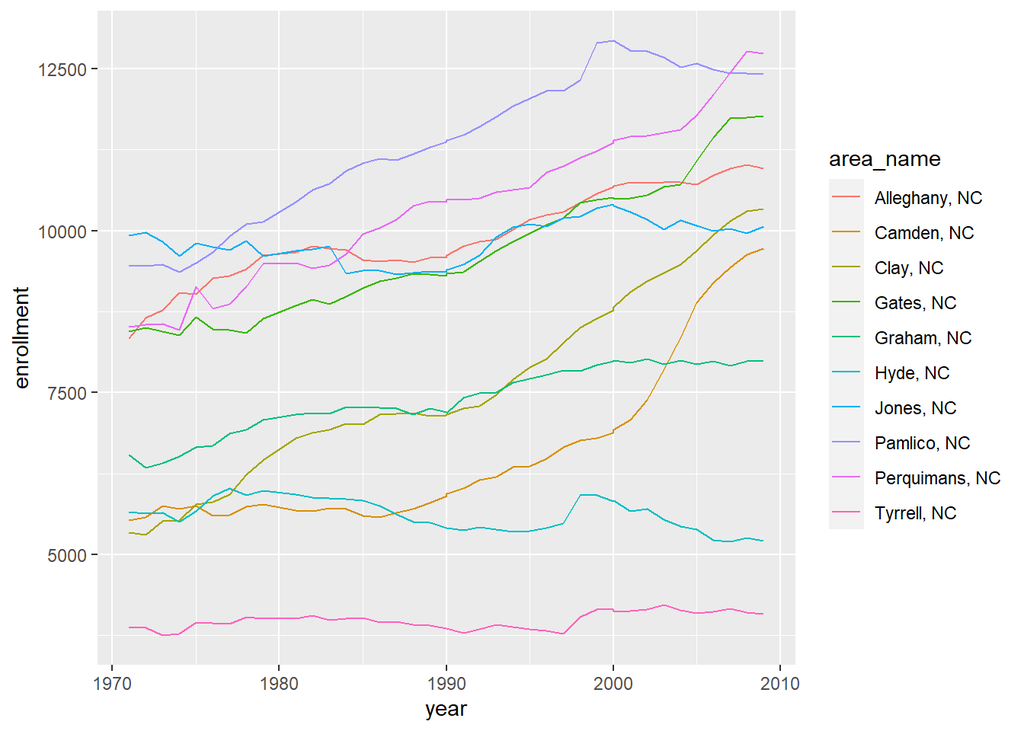

```r
plot(outfilepst$county, st = "NC", sort = "bottom", ncount = 10)
```

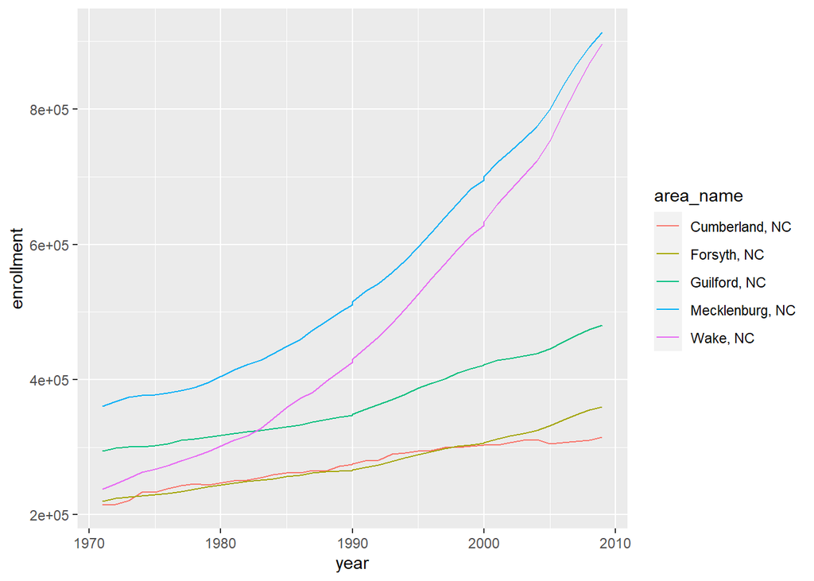

```r
plot(outfilepst$county)
```

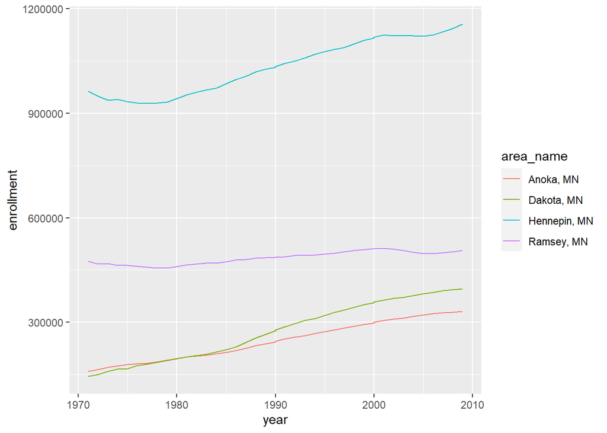

```r
plot(outfilepst$county, st = "MN", sort = "top", ncount = 4)
```